# イベントスタディ分析

UPDATE: 2024-12-13 16:46:19.719486

# はじめに

今回は、イベントスタディ分析の内容と実行方法をまとめておく。[Pythonで学ぶ効果検証入門](https://www.ohmsha.co.jp/book/9784274231162/)のDIDの章で紹介されているイベントスタディ分析を再現する。`fixest`パッケージについては下記が詳しい。`fixest`パッケージの使い方は末尾にまとめておく。

- [Fast Fixed-Effects Estimation: Short Introduction](https://cran.r-project.org/web/packages/fixest/vignettes/fixest_walkthrough.html#2_The_vcov_argument)
- [【R】固定効果モデルの推定がめっちゃ速いパッケージ { fixest}](https://keita43a.hatenablog.com/entry/2020/12/01/202122)
- [【R】差の差法でイベントスタディやるときのコード](https://keita43a.hatenablog.com/entry/2022/04/07/025153)

クラスター標準誤差については下記が詳しい。1つ目は`fixest`パッケージの作者が、`fixest`パッケージの標準誤差の計算方法について、小サンプル補正などを絡めて、他のパッケージとの違いを説明してくれているもの。

- [On standard-errors](https://cran.r-project.org/web/packages/fixest/vignettes/standard_errors.html)
- [Mathematical notes for estimatr](https://declaredesign.org/r/estimatr/articles/mathematical-notes.html)

## イベントスタディ分析

データは[Pythonで学ぶ効果検証入門](https://www.ohmsha.co.jp/book/9784274231162/)のDIDの章で利用されているものを利用する。ここでもまずは書籍に従って、DIDによる施策の分析をRでも再現しつつ、イベントスタディ分析の再現まで行う。

このデータセットは、アメリカの臓器提供登録率が変化するかどうかをカルフォルニア州を介入群として実験したデータセット。

- `State`: 27州が記録されている
- `Quarter`: Q42010 ~ Q12012の6期間
- `Quarter_Num`: `Quarter`のQ42010を1としたもの
- `Rate`: 登録率
- `IsTreatmentGroup`: 介入群であれば`1`、対照群であれば`0`
- `AfterTreatment`: `Quarter_Num`が4以降であれば`1`が立つ。これは期間を識別するフラグなので、介入の有無は関係ない。
- `IsTreatment`: `Quarter_Num`が4以降&`California`であれば`1`。これは介入期間かつ介入群を識別するフラグ。

```r
library(tidyverse)
library(fixest)

organ_full <- read_csv('~/Desktop/ch4_organ_donations_full.csv')
organ_full %>%
  filter(State == 'Alaska' | State == 'California') %>%
  print(n = 12)
```

```
## # A tibble: 12 × 7
##    State   Quarter  Rate Quarter_Num IsTreatmentGroup AfterTreatment IsTreatment
##    <chr>   <chr>   <dbl>       <dbl>            <dbl>          <dbl>       <dbl>
##  1 Alaska  Q42010  0.75            1                0              0           0
##  2 Alaska  Q12011  0.77            2                0              0           0
##  3 Alaska  Q22011  0.77            3                0              0           0
##  4 Alaska  Q32011  0.78            4                0              1           0
##  5 Alaska  Q42011  0.78            5                0              1           0
##  6 Alaska  Q12012  0.79            6                0              1           0
##  7 Califo… Q42010  0.267           1                1              0           0
##  8 Califo… Q12011  0.273           2                1              0           0
##  9 Califo… Q22011  0.274           3                1              0           0
## 10 Califo… Q32011  0.264           4                1              1           1
## 11 Califo… Q42011  0.261           5                1              1           1
## 12 Califo… Q12012  0.264           6                1              1           1
```

集計するとこのような結果になる。介入したカルフォルニア州では登録率が低下しているように見える

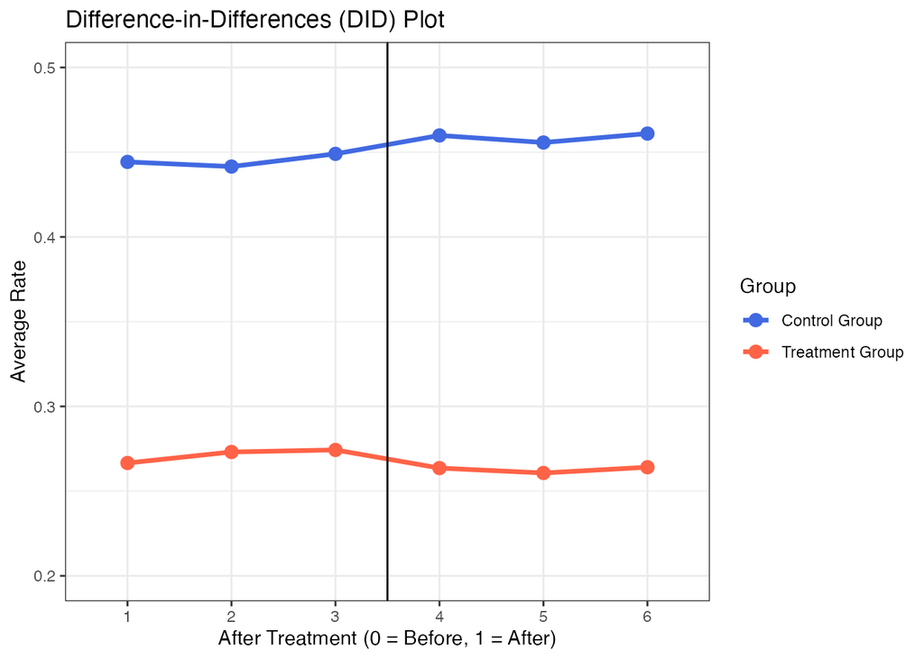

```r
organ_full %>%
  group_by(IsTreatmentGroup, Quarter_Num) %>%
  summarise(avg_rate = mean(Rate)) %>%
  ggplot(., aes(x = factor(Quarter_Num), y = avg_rate, color = factor(IsTreatmentGroup), group = factor(IsTreatmentGroup))) +
  geom_line(size = 1.2) +
  geom_point(size = 3) +
  geom_vline(xintercept = 3.5) +
  labs(
    title = "Difference-in-Differences (DID) Plot",
    x = "After Treatment (0 = Before, 1 = After)",
    y = "Average Rate",
    color = "Group"
  ) +
  ylim(c(0.2, 0.5)) +
  scale_color_manual(values = c("0" = "royalblue", "1" = "tomato"),
                     labels = c("0" = "Control Group", "1" = "Treatment Group")) +
  theme_bw()
```

書籍のモデルを再現する。知りたいのは$\tau$である。

$$Rate_{it} = \sum_{i=1}^{27} State_{i} + \sum_{t=1}^{6}Quarter\_Num_{t} +
\tau IsTreatment_{it} + \epsilon_{it}$$
書籍の結果とクラスター標準誤差がずれるのは、末尾に背景をまとめている。結果をみると、`-0.022`となっており、「臓器提供フォームの文言を変えたことで登録率が下がった」ことを意味する。

```r
f_did <- feols(
  Rate ~ IsTreatment | State + Quarter_Num,
  data = organ_full,
  cluster = 'State'
)
etable(f_did)
```

```
##                              f_did
## Dependent Var.:               Rate
##
## IsTreatment     -0.0225** (0.0061)
## Fixed-Effects:  ------------------
## State                          Yes
## Quarter_Num                    Yes
## _______________ __________________
## S.E.: Clustered          by: State
## Observations                   162
## R2                         0.97932
## Within R2                  0.00922
## ---
## Signif. codes: 0 '***' 0.001 '**' 0.01 '*' 0.05 '.' 0.1 ' ' 1
```

ここまでの再現で、データセットやDIDの結果への理解が深まったところで、イベントスタディ分析に移る。イベントスタディ分析の主たる目的は「介入後の効果は時間によって上下に変化する」ことを分析するところにある。介入後は効果が小さくても、時間が経過すると効果が大きくなる場合もある。

イベントスタディのモデルは下記の通り。

$$Y_{it} = \sum_{i=1}^{27} State_{i} + \sum_{t=1}^{6}Quarter\_Num_{t} +
\sum_{t=1}^{m-2} \nu_{t} W_{i} 1_{t} + \sum_{t=m}^{T} \tau_{t} W_{i}
1_{t} + \epsilon_{it}$$
イベントスタディ分析では、さきほどの分析とは異なり$\tau$は1つではなく、$m$期の施策効果であれば、$\tau_m$、$m+1$期施策効果であれば$\tau_{m+1}$と複数存在します。総じて、$m$期から$T$期までの$T-m$期の施策効果が係数$\tau_t$として表現される。そのため、この係数$\tau_t$を推定することで、イベントの効果を推定する。つまり、$T=6,m=4$であれば、$t=1,2$と$t=4,5,6$となり、$t=3$は基準点なので、モデルからは除外する。簡略化したイベントスタディ分析のモデルは下記の通り。

$$Rate_{it} = State_{i} + Quarter\_Num_{t} \\
+ \nu_{1} IsTreatmenrGroup_{i} * Quarter\_Num_{1} \\
+ \nu_{2} IsTreatmenrGroup_{i} * Quarter\_Num_{2} \\
+ \nu_{4} IsTreatmenrGroup_{i} * Quarter\_Num_{4} \\
+ \nu_{5} IsTreatmenrGroup_{i} * Quarter\_Num_{5} \\
+ \nu_{6} IsTreatmenrGroup_{i} * Quarter\_Num_{6} \\
+ \epsilon_{it} \\$$

イベントスタディ分析を行う前に、少しデータを前処理しておく。ここではパッケージによる便利な関数の使用は控え、分析方法への理解を深める。

```r
organ_event <- organ_full %>%
  mutate(
    # case文でもよい
    QuarterNum_1 = if_else(Quarter_Num == 1, 1, 0),
    QuarterNum_2 = if_else(Quarter_Num == 2, 1, 0),
    QuarterNum_4 = if_else(Quarter_Num == 4, 1, 0),
    QuarterNum_5 = if_else(Quarter_Num == 5, 1, 0),
    QuarterNum_6 = if_else(Quarter_Num == 6, 1, 0),
  )
organ_event %>%
  filter(State == 'Alaska' | State == 'California') %>%
  as.data.frame()
```

```
##         State Quarter   Rate Quarter_Num IsTreatmentGroup AfterTreatment
## 1      Alaska  Q42010 0.7500           1                0              0
## 2      Alaska  Q12011 0.7700           2                0              0
## 3      Alaska  Q22011 0.7700           3                0              0
## 4      Alaska  Q32011 0.7800           4                0              1
## 5      Alaska  Q42011 0.7800           5                0              1
## 6      Alaska  Q12012 0.7900           6                0              1
## 7  California  Q42010 0.2666           1                1              0
## 8  California  Q12011 0.2731           2                1              0
## 9  California  Q22011 0.2743           3                1              0
## 10 California  Q32011 0.2636           4                1              1
## 11 California  Q42011 0.2607           5                1              1
## 12 California  Q12012 0.2641           6                1              1
##    IsTreatment QuarterNum_1 QuarterNum_2 QuarterNum_4 QuarterNum_5 QuarterNum_6
## 1            0            1            0            0            0            0
## 2            0            0            1            0            0            0
## 3            0            0            0            0            0            0
## 4            0            0            0            1            0            0
## 5            0            0            0            0            1            0
## 6            0            0            0            0            0            1
## 7            0            1            0            0            0            0
## 8            0            0            1            0            0            0
## 9            0            0            0            0            0            0
## 10           1            0            0            1            0            0
## 11           1            0            0            0            1            0
## 12           1            0            0            0            0            1
```

実行結果がこちら。

```r
# fl = 'Rate ~
#   QuarterNum_1*IsTreatmentGroup +
#   QuarterNum_2*IsTreatmentGroup +
#   QuarterNum_4*IsTreatmentGroup +
#   QuarterNum_5*IsTreatmentGroup +
#   QuarterNum_6*IsTreatmentGroup | State + Quarter_Num'

f_pre <- paste0("IsTreatmentGroup", "*QuarterNum_", c(1:2, 4:6), collapse = " + ")
fl <- paste0('Rate ~ ', f_pre, ' | State + Quarter_Num')

f_event <- feols(
  fml = as.formula(fl),
  data = organ_event,
  cluster = 'State'
)
etable(f_event)
```

```
##                                             f_event
## Dependent Var.:                                Rate
##
## IsTreatmentGroup x QuarterNum_1    -0.0029 (0.0051)
## IsTreatmentGroup x QuarterNum_2   0.0063** (0.0023)
## IsTreatmentGroup x QuarterNum_4 -0.0216*** (0.0050)
## IsTreatmentGroup x QuarterNum_5 -0.0203*** (0.0045)
## IsTreatmentGroup x QuarterNum_6   -0.0222* (0.0100)
## Fixed-Effects:                  -------------------
## State                                           Yes
## Quarter_Num                                     Yes
## _______________________________ ___________________
## S.E.: Clustered                           by: State
## Observations                                    162
## R2                                          0.97934
## Within R2                                   0.00979
## ---
## Signif. codes: 0 '***' 0.001 '**' 0.01 '*' 0.05 '.' 0.1 ' ' 1
```

あとはこれを可視化する。

```r
f_event_df <- tibble(
  label = c(names(f_event$coefficients), 't=3'),
  time = c(1:2, 4:6, 3),
  coef = c(f_event$coefficients, 0),
  se = c(f_event$se, 0),
  n = nrow(organ_event)) %>%
  mutate(
    ci_lwr = coef - qt(0.975, df = n)*se,
    ci_upr = coef + qt(0.975, df = n)*se
  )
f_event_df
```

```
## # A tibble: 6 × 7
##   label                          time     coef      se     n   ci_lwr   ci_upr
##   <chr>                         <dbl>    <dbl>   <dbl> <int>    <dbl>    <dbl>
## 1 IsTreatmentGroup:QuarterNum_1     1 -0.00294 0.00508   162 -0.0130   0.00710
## 2 IsTreatmentGroup:QuarterNum_2     2  0.00630 0.00227   162  0.00182  0.0108
## 3 IsTreatmentGroup:QuarterNum_4     4 -0.0216  0.00503   162 -0.0315  -0.0116
## 4 IsTreatmentGroup:QuarterNum_5     5 -0.0203  0.00447   162 -0.0291  -0.0115
## 5 IsTreatmentGroup:QuarterNum_6     6 -0.0222  0.0100    162 -0.0419  -0.00239
## 6 t=3                               3  0       0         162  0        0
```

プロットを見る限り、施策介入後は`-2%`近辺を推移しているため、施策実行後から時間が経過しても、この期間においては変化してないことがわかる。

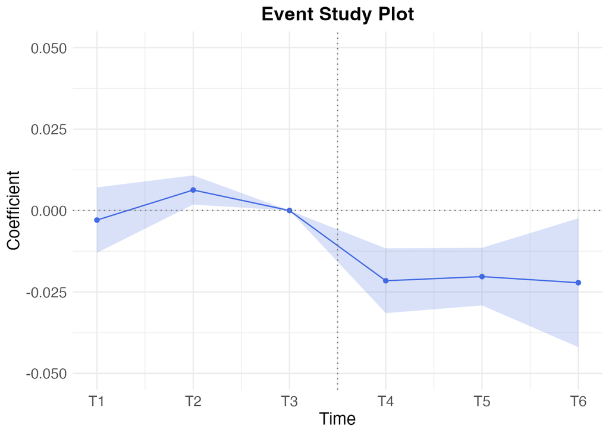

```r
ggplot(f_event_df, aes(x = time, y = coef)) +
  geom_line(color = 'royalblue') +
  geom_point(color = 'royalblue') +
  geom_ribbon(aes(ymin = ci_lwr, ymax = ci_upr), alpha = 0.2, fill = 'royalblue') +
  geom_vline(xintercept = 3.5, linetype = 'dotted', color = 'gray50') +
  geom_hline(yintercept = 0, linetype = 'dotted', color = 'gray50') +
  scale_x_continuous(breaks = 1:6, labels = paste("T", 1:6, sep = "")) +
  coord_cartesian(ylim = c(-0.05, 0.05)) +
  labs(
    title = "Event Study Plot",
    x = "Time",
    y = "Coefficient"
  ) +
  theme_minimal() +
  theme(
    plot.title = element_text(size = 16, face = "bold", hjust = 0.5),
    axis.title = element_text(size = 14),
    axis.text = element_text(size = 12)
  )
```

## 介入時期が一律ではない場合

さきほどの例では、介入時期がすべての州で同一だったが、実際は介入時期がずれる可能性がある。例えば、前回のノートで扱った[Mixtape](https://github.com/scunning1975/mixtape/blob/master/R/castle_1.R)の「Castle-doctrine statutes and homicides」の章のデータセットは、異なるタイミングで行われた銃の規制に関するデータセットになっている。

- `Alabama`に介入したのは2006年なので、2006年を基準に前後のダミーフラグを作成する。2005年が`lead1`で、2007年が`lag1`になる。
- `Texas`に介入したのは2007年なので、2007年を基準に前後のダミーフラグを作成する。2006年が`lead1`で、2008年が`lag1`になる。
- `Wyoming`に介入していないので`NA`しかない。説明のために｀NA`にしているが、実際には0で埋める。

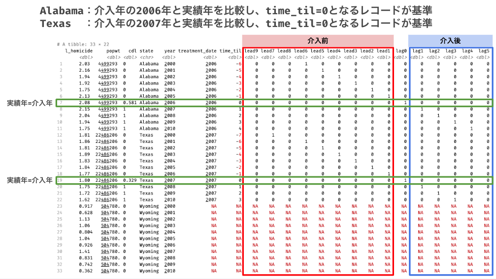

```r
castle <- read_csv('~/Desktop/castle.csv')

castle2 <- castle %>%
  select(l_homicide, popwt, cdl, state, year, treatment_date) %>%
  mutate(
    time_til = year - treatment_date,
    lead9 = case_when(time_til == -9 ~ 1, TRUE ~ 0),
    lead8 = case_when(time_til == -8 ~ 1, TRUE ~ 0),
    lead7 = case_when(time_til == -7 ~ 1, TRUE ~ 0),
    lead6 = case_when(time_til == -6 ~ 1, TRUE ~ 0),
    lead5 = case_when(time_til == -5 ~ 1, TRUE ~ 0),
    lead4 = case_when(time_til == -4 ~ 1, TRUE ~ 0),
    lead3 = case_when(time_til == -3 ~ 1, TRUE ~ 0),
    lead2 = case_when(time_til == -2 ~ 1, TRUE ~ 0),
    lead1 = case_when(time_til == -1 ~ 1, TRUE ~ 0),
    lag0 = case_when(time_til == 0 ~ 1, TRUE ~ 0),
    lag1 = case_when(time_til == 1 ~ 1, TRUE ~ 0),
    lag2 = case_when(time_til == 2 ~ 1, TRUE ~ 0),
    lag3 = case_when(time_til == 3 ~ 1, TRUE ~ 0),
    lag4 = case_when(time_til == 4 ~ 1, TRUE ~ 0),
    lag5 = case_when(time_til == 5 ~ 1, TRUE ~ 0)
    )

event_study_formula <- as.formula(
  paste("l_homicide ~ ",
        paste(
          paste(paste("lead", 1:9, sep = ""), collapse = " + "),
          paste(paste("lag", 1:5, sep = ""), collapse = " + "), sep = " + "),
        "| year + state"
  ),
)
event_study_reg <- lfe::felm(
  event_study_formula,
  weights = castle2$popwt,
  data = castle2)

summary(event_study_reg)
```

```
##
## Call:
##    lfe::felm(formula = event_study_formula, data = castle2, weights = castle2$popwt)
##
## Weighted Residuals:
##     Min      1Q  Median      3Q     Max
## -787.73 -166.65    6.99  150.48  884.18
##
## Coefficients:
##        Estimate Std. Error t value Pr(>|t|)
## lead1 -0.038693   0.034802  -1.112   0.2668
## lead2  0.002261   0.035967   0.063   0.9499
## lead3  0.006643   0.036762   0.181   0.8567
## lead4 -0.006975   0.037114  -0.188   0.8510
## lead5  0.018607   0.037330   0.498   0.6184
## lead6  0.053712   0.040069   1.340   0.1807
## lead7 -0.063573   0.050582  -1.257   0.2094
## lead8 -0.203023   0.082432  -2.463   0.0141 *
## lead9 -0.285209   0.296400  -0.962   0.3364
## lag1   0.079512   0.034807   2.284   0.0228 *
## lag2   0.085099   0.036101   2.357   0.0188 *
## lag3   0.079865   0.038332   2.084   0.0377 *
## lag4   0.041934   0.043856   0.956   0.3395
## lag5   0.089586   0.066579   1.346   0.1791
## ---
## Signif. codes:  0 '***' 0.001 '**' 0.01 '*' 0.05 '.' 0.1 ' ' 1
##
## Residual standard error: 269.3 on 476 degrees of freedom
## Multiple R-squared(full model): 0.9367   Adjusted R-squared: 0.927
## Multiple R-squared(proj model): 0.06774   Adjusted R-squared: -0.07523
## F-statistic(full model):96.52 on 73 and 476 DF, p-value: < 2.2e-16
## F-statistic(proj model): 2.471 on 14 and 476 DF, p-value: 0.002202
```

後は先程と同様に可視化すれば良い。

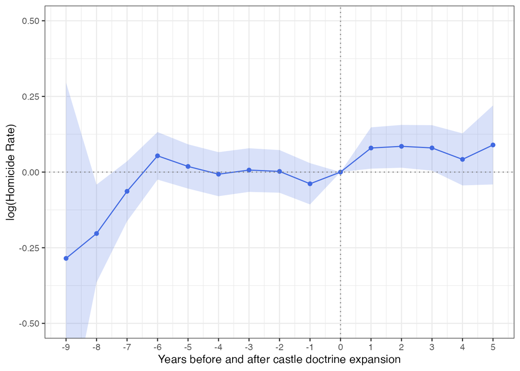

```r
# order of the coefficients for the plot
plot_order <- c("lead9", "lead8", "lead7",
                "lead6", "lead5", "lead4", "lead3",
                "lead2", "lead1", "lag1",
                "lag2", "lag3", "lag4", "lag5")
leadslags_plot <- tibble(
  sd = c(event_study_reg$se[plot_order], 0),
  mean = c(coef(event_study_reg)[plot_order], 0),
  label = c(-9,-8,-7,-6, -5, -4, -3, -2, -1, 1,2,3,4,5, 0)
) %>%
  mutate(
    ymin = mean-1.96*sd,
    ymax = mean+1.96*sd
  )

ggplot(leadslags_plot, aes(x = label, y = mean)) +
  geom_line(color = 'royalblue') +
  geom_point(color = 'royalblue') +
  geom_ribbon(aes(ymin = ymin, ymax = ymax), alpha = 0.2, fill = 'royalblue') +
  geom_vline(xintercept = 0, linetype = 'dotted', color = 'gray50') +
  geom_hline(yintercept = 0, linetype = 'dotted', color = 'gray50') +
  scale_x_continuous(breaks = -9:5) +
  coord_cartesian(ylim = c(-0.5, 0.5)) +
  xlab("Years before and after castle doctrine expansion") +
  ylab("log(Homicide Rate)") +
  theme_bw()
```

## `fixest`パッケージの使用方法

作者のイントロダクションを見ながら`fixest`パッケージの使用方法を簡単にまとめておく。

- [Fast Fixed-Effects Estimation: Short Introduction](https://cran.r-project.org/web/packages/fixest/vignettes/fixest_walkthrough.html#2_The_vcov_argument)

基本的にはRで回帰を実行するときのようにフォーミュラを記載すれば良い。固定効果を追加したい場合は、`|`で区切って変数を追加していく。

```
feols(y ~  x1 + x2 + x3 + x4 | a1 + a2 + a3 + a4, data)
```

```r
organ_full %>%
  group_by(IsTreatmentGroup, AfterTreatment) %>%
  summarise(avg_rate = mean(Rate))
```

```
## # A tibble: 4 × 3
## # Groups:   IsTreatmentGroup [2]
##   IsTreatmentGroup AfterTreatment avg_rate
##              <dbl>          <dbl>    <dbl>
## 1                0              0    0.445
## 2                0              1    0.459
## 3                1              0    0.271
## 4                1              1    0.263
```

2x2差分の差分法を回帰モデルで実行する方法は下記の通り。

```r
feols(Rate ~ IsTreatmentGroup*AfterTreatment, data = organ_full)
```

```
## OLS estimation, Dep. Var.: Rate
## Observations: 162Standard-errors: IID
##                                  Estimate Std. Error   t value  Pr(>|t|)
## (Intercept)                      0.444931   0.017047 26.100751 < 2.2e-16 ***
## IsTreatmentGroup                -0.173597   0.088577 -1.959846  0.051773 .
## AfterTreatment                   0.013926   0.024108  0.577645  0.564326
## IsTreatmentGroup:AfterTreatment -0.022459   0.125267 -0.179289  0.857941
## ---
## Signif. codes:  0 '***' 0.001 '**' 0.01 '*' 0.05 '.' 0.1 ' ' 1
## RMSE: 0.148682   Adj. R2: 0.036196
```

固定効果モデルを実行する方法は下記の通り。クラスター標準誤差ももちろん利用可能。`cluster`引数に指定すれば良い。

```r
f1 <- feols(
  Rate ~ IsTreatment | State + Quarter_Num,
  data = organ_full,
  cluster = 'State'
)
summary(f1)
```

```
## OLS estimation, Dep. Var.: Rate
## Observations: 162Fixed-effects: State: 27,  Quarter_Num: 6Standard-errors: Clustered (State)
##              Estimate Std. Error  t value  Pr(>|t|)
## IsTreatment -0.022459   0.006131 -3.66304 0.0011185 **
## ---
## Signif. codes:  0 '***' 0.001 '**' 0.01 '*' 0.05 '.' 0.1 ' ' 1
## RMSE: 0.021982     Adj. R2: 0.974196
##                  Within R2: 0.009221
```

他の書き方として、`summary()`で渡しても良いとのこと。

```r
f2 <- feols(
  Rate ~ IsTreatment | State + Quarter_Num,
  data = organ_full
)
summary(f2, cluster = 'State')
```

```
## OLS estimation, Dep. Var.: Rate
## Observations: 162Fixed-effects: State: 27,  Quarter_Num: 6Standard-errors: Clustered (State)
##              Estimate Std. Error  t value  Pr(>|t|)
## IsTreatment -0.022459   0.006131 -3.66304 0.0011185 **
## ---
## Signif. codes:  0 '***' 0.001 '**' 0.01 '*' 0.05 '.' 0.1 ' ' 1
## RMSE: 0.021982     Adj. R2: 0.974196
##                  Within R2: 0.009221
```

固定効果の2つのカテゴリについてクラスター標準誤差を計算したい場合、`summary()`の中で`se = "twoway"`を利用する。1つの場合は`cluster`、2つの場合は`twoway`、3つの場合は`threeway`、4つの場合は`fourway`を利用する。他にも、`standard`、`hetero`も利用できる。

```r
f3 <- feols(
  Rate ~ IsTreatment | State + Quarter_Num,
  data = organ_full
)
summary(f3, se = 'twoway')
```

```
## OLS estimation, Dep. Var.: Rate
## Observations: 162Fixed-effects: State: 27,  Quarter_Num: 6Standard-errors: Clustered (State & Quarter_Num)
##              Estimate Std. Error  t value  Pr(>|t|)
## IsTreatment -0.022459   0.005197 -4.32173 0.0075582 **
## ---
## Signif. codes:  0 '***' 0.001 '**' 0.01 '*' 0.05 '.' 0.1 ' ' 1
## RMSE: 0.021982     Adj. R2: 0.974196
##                  Within R2: 0.009221
```

もしくは、`vcov`引数を利用しても同じ。オプションは`cluster`、`twoway`、`newey_west`、`driscoll_kraay`、`conley`が用意されている。

```r
f4 <- feols(
  Rate ~ IsTreatment | State + Quarter_Num,
  data = organ_full,
  vcov = 'twoway'
)
summary(f4)
```

```
## OLS estimation, Dep. Var.: Rate
## Observations: 162Fixed-effects: State: 27,  Quarter_Num: 6Standard-errors: Clustered (State & Quarter_Num)
##              Estimate Std. Error  t value  Pr(>|t|)
## IsTreatment -0.022459   0.005197 -4.32173 0.0075582 **
## ---
## Signif. codes:  0 '***' 0.001 '**' 0.01 '*' 0.05 '.' 0.1 ' ' 1
## RMSE: 0.021982     Adj. R2: 0.974196
##                  Within R2: 0.009221
```

クラスター標準誤差の計算については、パッケージの作者が下記の通りnoteを用意してくれている。一部抜粋すると、

- [On standard-errors](https://cran.r-project.org/web/packages/fixest/vignettes/standard_errors.html)

> 標準誤差は推定の重要な要素であると言うのは婉曲表現です。文字通り、論文の結果は標準誤差に依存します。したがって、標準誤差を計算する従来の「最良」の方法が存在しないのは残念です。 たとえば、さまざまなソフトウェアでまったく同じ推定を実行すると、異なる標準誤差が得られることは珍しくありません。最初に「バグがあるに違いない」と思ったとしても、その考えは脇に置いてください。バグなど存在しないのですから。多くの場合、それは開発者が小規模サンプル補正に関して行った選択に帰着しますが、驚くべきことに、実装に関しては多くの自由度があります。 複数の定義があると混乱が生じる可能性があるため、このドキュメントの目的は、このパッケージの標準誤差計算の面倒な詳細を明らかにすることです。

例えば、`estimatr`パッケージの下記の実行結果と同じもの(詳細までは調べていない)を得るには、小規模サンプル補正やクラスター標準誤差の計算方法を調整する必要がある。

```r
estimatr::lm_robust(Rate ~ IsTreatment,
  fixed_effects = State + Quarter_Num,
  data = organ_full,
  clusters = State,
  se_type = 'CR0'
)
```

```
##                Estimate  Std. Error   t value     Pr(>|t|)    CI Lower
## IsTreatment -0.02245897 0.005903444 -3.804385 0.0007770557 -0.03459368
##                CI Upper DF
## IsTreatment -0.01032427 26
```

`ssc`は小規模サンプル補正のオプション。

```r
feols(
  Rate ~ IsTreatment | State + Quarter_Num,
  data = organ_full,
  cluster = 'State',
  ssc = ssc(adj = FALSE, cluster.adj = FALSE)
)
```

```
## OLS estimation, Dep. Var.: Rate
## Observations: 162Fixed-effects: State: 27,  Quarter_Num: 6Standard-errors: Clustered (State)
##              Estimate Std. Error  t value   Pr(>|t|)
## IsTreatment -0.022459   0.005903 -3.80439 0.00077706 ***
## ---
## Signif. codes:  0 '***' 0.001 '**' 0.01 '*' 0.05 '.' 0.1 ' ' 1
## RMSE: 0.021982     Adj. R2: 0.974196
##                  Within R2: 0.009221
```

`fixef()`を利用すれば、固定効果のパラメタを確認できる。いくつかのサンプルについてのみ、`plot(fixef(f5))`で可視化できる。

```r
f5 <- feols(
  Rate ~ IsTreatment | State,
  data = organ_full,
  cluster = 'State'
)
fixef(f5)
```

```
## $State
##               Alaska              Arizona           California
##            0.7733333            0.2404667            0.2713333
##             Colorado          Connecticut District of Columbia
##            0.6678500            0.3931500            0.3432833
##              Florida               Hawaii            Louisiana
##            0.3963833            0.4209167            0.5566000
##             Maryland             Michigan            Minnesota
##            0.4657167            0.2324667            0.5276167
##             Missouri              Montana             Nebraska
##            0.4073500            0.6548833            0.4425167
##        New Hampshire           New Jersey             New York
##            0.5441333            0.3125833            0.1297833
##       North Carolina                 Ohio         Pennsylvania
##            0.5249833            0.5656000            0.4542833
##       South Carolina            Tennessee             Virginia
##            0.2690500            0.3352000            0.3409500
##           Washington            Wisconsin              Wyoming
##            0.5870167            0.5721167            0.5910000
##
## attr(,"class")
## [1] "fixest.fixef" "list"
## attr(,"exponential")
## [1] FALSE
```

`etable()`を利用すれば、複数のモデルを説明と共にレイアウトして表示してくれる。

```r
etable(f1, f5)
```

```
##                                 f1                    f5
## Dependent Var.:               Rate                  Rate
##
## IsTreatment     -0.0225** (0.0061) -0.0085*** (1.77e-18)
## Fixed-Effects:  ------------------ ---------------------
## State                          Yes                   Yes
## Quarter_Num                    Yes                    No
## _______________ __________________ _____________________
## S.E.: Clustered          by: State             by: State
## Observations                   162                   162
## R2                         0.97932               0.97702
## Within R2                  0.00922               0.00125
## ---
## Signif. codes: 0 '***' 0.001 '**' 0.01 '*' 0.05 '.' 0.1 ' ' 1
```

本ノートでも説明しているイベントスタディ分析も簡単にできる。

```r
f_event <- feols(
  Rate ~ i(Quarter_Num, IsTreatmentGroup, ref = 3) | State + Quarter_Num,
  data = organ_full,
  cluster = 'State'
  )
f_event
```

```
## OLS estimation, Dep. Var.: Rate
## Observations: 162Fixed-effects: State: 27,  Quarter_Num: 6Standard-errors: Clustered (State)
##                                  Estimate Std. Error   t value   Pr(>|t|)
## Quarter_Num::1:IsTreatmentGroup -0.002942   0.005084 -0.578719 0.56775872
## Quarter_Num::2:IsTreatmentGroup  0.006296   0.002266  2.778832 0.00999724 **
## Quarter_Num::4:IsTreatmentGroup -0.021565   0.005034 -4.284177 0.00022209 ***
## Quarter_Num::5:IsTreatmentGroup -0.020292   0.004473 -4.536282 0.00011432 ***
## Quarter_Num::6:IsTreatmentGroup -0.022165   0.010013 -2.213610 0.03583451 *
## ---
## Signif. codes:  0 '***' 0.001 '**' 0.01 '*' 0.05 '.' 0.1 ' ' 1
## RMSE: 0.021976     Adj. R2: 0.973385
##                  Within R2: 0.009787
```

`iplot()`で可視化できる。

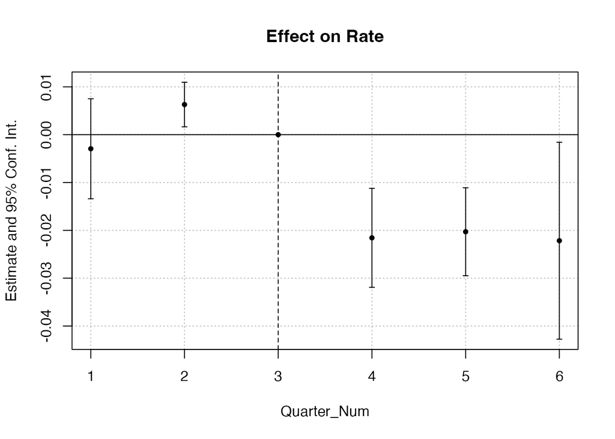

```r
iplot(f_event)
```